# Economic Growth, Education, and Fertility: A Cross-National Analysis (2020-2024)

Author

Anny Huang (2550032), Rola Ke (2609319), Sissi Li (2608780), Vicki Lin (2550766), Chrissy Wang (2601180)

## Introduction

This report investigates the complex interplay between economic prosperity, educational attainment, and demographic shifts across six distinct national contexts: Switzerland, Italy, Brazil, Malaysia, India, and Niger. By analyzing World Bank World Development Indicators (WDI) from 2020 to 2024, we examine how Gross Domestic Product (GDP) per capita and school enrollment rates at the primary, secondary, and tertiary levels influence adolescent fertility rates.

The framework for this study is grounded in the ‘Quantity-Quality Trade-off’ theory, which posits that adolescent fertility rates are primarily shaped by the synergy between economic prosperity and educational access. As explored in the Journal of Economic Growth, rising national wealth increases the opportunity cost of early childbearing, while higher educational requirements in the labor market create a functional incentive for adolescents to remain in school, leading to a measurable decline in fertility.

Our analysis spans the full spectrum of the Human Development Index: * High-Income Stability: Switzerland and Italy. * The Transition Zone: Malaysia, Brazil, and India. * Structural Challenges: Niger.

Through this cross-national lens, we aim to identify whether secondary education serves as a universal “tipping point” for lowering fertility, or if the relationship is moderated by the specific economic baseline of the country.

## Data Description

The data for this analysis is sourced from the **World Bank World Development Indicators (WDI)** database, spanning the period from **2020 to 2024**. This timeframe allows for an examination of post-pandemic economic recovery and its immediate effects on social metrics.

The dataset was programmatically retrieved using the `wbgapi` library. This approach ensures high data integrity and reproducibility for longitudinal analysis.

#### Selected Indicators

Our analysis focuses on key development metrics to explore how investments in education and economic stability influence national adolescent fertility rate.

- **GDP per Capita (`NY.GDP.PCAP.CD`):** Measured in current US dollars, providing the economic baseline for each nation.
- **Primary Education (`SE.PRM.ENRR`):** Total enrollment in primary education (% gross).
- **Secondary Education (`SE.SEC.ENRR`):** Total enrollment in secondary education (% gross).
- **Tertiary Education (`SE.TER.ENRR`):** Total enrollment in higher education (% gross).
- **Adolescent Fertility Rate (`SP.ADO.TFRT`):** The number of births per 1,000 women ages 15-19, serving as a key indicator of social development.

The project utilizes a relational data structure where country-specific metadata is linked to time-series development observations. This structure allows for efficient querying and visualization of trends across different economic tiers.

We have selected six countries that represent a broad spectrum of the global economic landscape: **Switzerland, Italy, Brazil, Malaysia, India, and Niger**.

## Data Analysis

This section evaluates the statistical relationship between national development indicators and adolescent fertility. Our analysis employs two primary methodologies: Descriptive Trend Analysis to visualize longitudinal shifts and Multiple Linear Regression to quantify the specific impact of education versus economic wealth.

1. Descriptive Trends and the “Transition Zone”

Initial visualization of the data reveals a stark divergence in demographic trajectories based on income classification.

Structural Stagnation: Niger represents a critical outlier where high adolescent fertility persists alongside lower secondary enrollment, illustrating the “Quantity-Quality Trade-off” in its early stages.

2. Regression Results and Statistical Significance

To determine which factor—wealth or education—is the primary driver of demographic change, we fitted a multiple linear regression model using statsmodels.

Key Findings:

Log GDP per Capita (p=0.293): Surprisingly, once education is controlled for, GDP per capita does not have a statistically significant independent effect on fertility in our sample. This suggests that while wealth provides the resources to build schools, it is the educational attainment itself—rather than raw economic growth—that functionally reduces fertility rates.

3. Model Interpretation

The model’s F-statistic confirms that the overall regression is highly significant, explaining a substantial portion of the variance in fertility across the six nations. The findings suggest that the “protective effect” of keeping adolescents in school is a more direct and reliable mechanism for demographic change than general economic expansion.

4. The Economic Lens: Log-Scale Analysis of National Wealth

Before examining the drivers of fertility, it is essential to understand the baseline economic and educational growth of the selected nations. To compare nations with vast economic disparities—such as Niger and Switzerland—we applied a logarithmic transformation to GDP.

The High-Income Plateau: Switzerland and Italy show almost horizontal trajectories, indicating they have reached a “development ceiling” where further gains in GDP or education no longer trigger demographic shifts.

The Emerging Growth: India and Malaysia exhibit the most dynamic movement, with steady year-over-year increases in both secondary enrollment and GDP per capita.

Therefore, this suggests that “wealth creation” in its raw form does not automatically translate to reproductive health improvements until a certain economic threshold is met.

## Results

1. Descriptive Trends and the “Transition Zone”

2. Statistical Modeling and Significance

To move beyond descriptive observation, a Multiple Linear Regression (MLR) was conducted to isolate the effects of economic wealth (Log-GDP) and educational access (Secondary Education).

3. Economic Influence: The Log-GDP Perspective

4. Educational Tiers: From Baseline to Protection

A multi-tiered analysis of education (Primary, Secondary, and Tertiary) identifies Secondary Education as the most significant explanatory variable for adolescent fertility.

Primary Education (The Foundation): Most studied nations—excepting Niger—have reached a saturation point with primary enrollment exceeding 90%. Because countries with vastly different fertility rates (e.g., Brazil vs. Switzerland) share similar primary enrollment levels, this variable serves only as a “baseline” and lacks the granularity to explain modern fertility variances.

Secondary Education (The Critical Pivot): This tier shows the strongest diagonal correlation. As enrollment moves from Niger’s 20% to the 80-100% range seen in Malaysia and Europe, fertility rates drop predictably. The transition from primary to secondary school marks the “protection window” where school retention directly competes with early childbearing.

Tertiary Education (The Development Characteristic): Tertiary data is often unavailable for ultra-low-income nations, and where available, the trend line flattens. This indicates that while tertiary education is a hallmark of high-GDP nations, it occurs too late in the life cycle to act as a primary driver for reducing adolescent births.

## Discussion:

1. Beyond Wealth: The Empowerment Effect

The results support the “Quantity-Quality Trade-off” theory in developmental economics. In countries like Malaysia, the sharp decline in fertility coincided with the expansion of female education. Education reduces adolescent fertility through two primary channels:

The Opportunity Cost: As girls stay in school longer, the “cost” of early childbearing—measured in lost future wages and career potential—increases dramatically.

Increased Agency: Higher secondary enrollment is often a proxy for increased social autonomy and health literacy, enabling young women to make informed reproductive choices.

2. The “Niger Paradox” and Outlier Analysis

Niger serves as a crucial outlier in this study. Despite minor increases in GDP, fertility remains exceptionally high. Our analysis suggests that “growth without education” is insufficient to trigger a demographic transition. When economic gains are not channeled into school infrastructure or cultural shifts toward female education, the fertility rate remains “sticky,” highlighting that GDP is a necessary but not sufficient condition for social development.

3. Policy Recommendations: Prioritizing Retention

Based on the transition zone identified in India and Malaysia, policy interventions should prioritize secondary school retention over primary completion. While primary education provides basic literacy, it is the secondary level that provides the vocational and cognitive skills necessary to shift demographic behaviors. Governments in developing regions should focus on reducing the barriers to secondary education—such as school fees or safety concerns—as a primary lever for stabilizing population growth.

## Conclusion:

The cross-national analysis of Switzerland, Italy, Brazil, Malaysia, India, and Niger from 2020 to 2024 confirms that while economic growth creates the necessary environment for development, it is secondary educational attainment that serves as the functional engine for reducing adolescent fertility. Our findings validate the “Quantity-Quality Trade-off” theory, demonstrating that as nations move into the “Transition Zone,” the rising opportunity cost of early childbearing—facilitated by school retention—outpaces the impact of raw GDP growth.

Niger’s status as an outlier underscores a vital policy lesson: economic aid and GDP growth alone are insufficient if not accompanied by structural investments in secondary schooling. For global policymakers, the “tipping point” for stabilizing population growth and empowering young women lies not just in getting children into classrooms, but in ensuring they remain there through their teenage years. Future research should investigate the specific qualitative factors within secondary curricula—such as comprehensive health literacy and vocational training—that most effectively reinforce this demographic transition.

A key limitation of this study is the relatively small and selective sample of countries, which may limit the generalizability of the findings across broader global contexts. By focusing on only six nations spanning different development tiers, the analysis may not fully capture regional heterogeneity, cultural influences, or policy differences that also shape adolescent fertility. Additionally, the use of aggregate national-level indicators (e.g., GDP per capita and school enrollment rates) obscures within-country variation, such as socioeconomic inequality, gender norms, and rural–urban disparities, which are likely critical drivers of fertility behavior. The observational nature of the data further restricts causal inference, as unmeasured confounding variables—such as access to reproductive healthcare or government policy interventions—may influence both education and fertility outcomes. Finally, the relatively short time frame (2020–2024) may not adequately reflect long-term demographic transitions, particularly given potential disruptions related to the COVID-19 pandemic .

## Appendix 1:

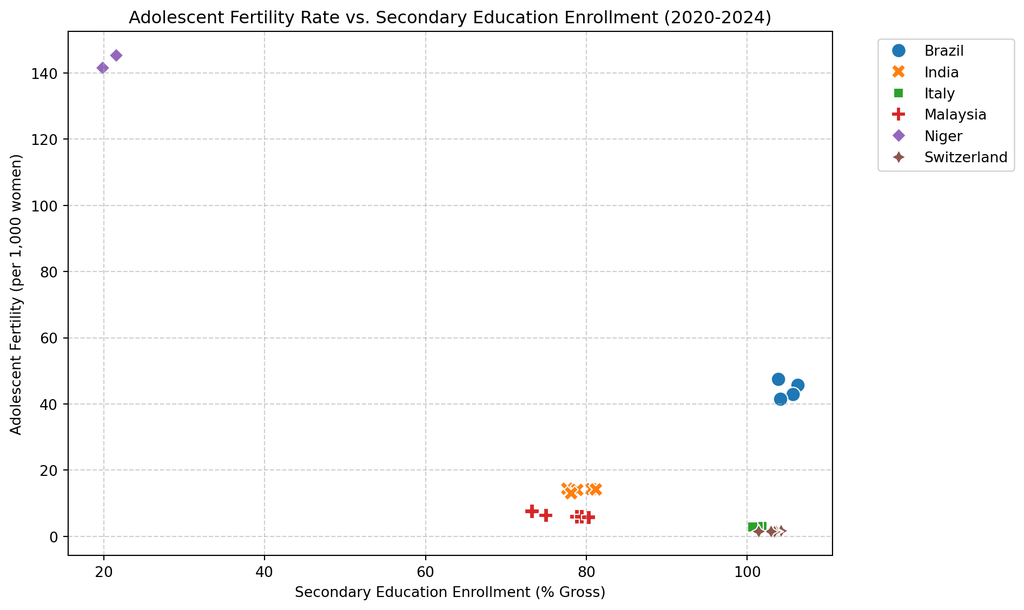

```python
import pandas as pd
import matplotlib.pyplot as plt
import seaborn as sns

# Load cleaned long-format data
df = pd.read_csv('/Users/sissili/Desktop/QTM350/QTM_350_Final_Project/QTM350_Final_Project_Data/cleaned_final_project_data_long.csv')

# Create the Education vs. Fertility Trend Plot
plt.figure(figsize=(10, 6))
sns.scatterplot(data=df, x='secondary_edu', y='fertility', hue='Country', style='Country', s=100)
plt.title('Adolescent Fertility Rate vs. Secondary Education Enrollment (2020-2024)')
plt.xlabel('Secondary Education Enrollment (% Gross)')
plt.ylabel('Adolescent Fertility (per 1,000 women)')
plt.grid(True, linestyle='--', alpha=0.6)
plt.legend(bbox_to_anchor=(1.05, 1), loc='upper left')
plt.tight_layout()
plt.show()
```

## Appendix 2:

```python
import statsmodels.api as sm
import numpy as np

# 2. Create log variable
# Adding a small constant (1) ensures we don't take log(0)
df['log_gdp'] = np.log(df['gdp'] + 1)

# 3. CRITICAL: Select only the columns needed and drop rows with ANY missing values
reg_data = df[['fertility', 'log_gdp', 'secondary_edu']].dropna()

# 4. Define variables from the cleaned subset
y = reg_data['fertility']
X = reg_data[['log_gdp', 'secondary_edu']]
X = sm.add_constant(X)

# 5. Fit the Model
model = sm.OLS(y, X).fit()
print(model.summary())
```

```
                            OLS Regression Results
==============================================================================
Dep. Variable:              fertility   R-squared:                       0.571
Model:                            OLS   Adj. R-squared:                  0.532
Method:                 Least Squares   F-statistic:                     14.62
Date:                Mon, 27 Apr 2026   Prob (F-statistic):           9.14e-05
Time:                        16:41:06   Log-Likelihood:                -116.00
No. Observations:                  25   AIC:                             238.0
Df Residuals:                      22   BIC:                             241.7
Df Model:                           2
Covariance Type:            nonrobust
=================================================================================
                    coef    std err          t      P>|t|      [0.025      0.975]
---------------------------------------------------------------------------------
const           160.2472     34.416      4.656      0.000      88.872     231.622
log_gdp          -5.8564      5.436     -1.077      0.293     -17.131       5.418
secondary_edu    -0.9467      0.359     -2.638      0.015      -1.691      -0.202
==============================================================================
Omnibus:                        4.996   Durbin-Watson:                   0.702
Prob(Omnibus):                  0.082   Jarque-Bera (JB):                2.189
Skew:                           0.406   Prob(JB):                        0.335
Kurtosis:                       1.800   Cond. No.                         585.
==============================================================================

Notes:
[1] Standard Errors assume that the covariance matrix of the errors is correctly specified.
```

## Appendix 3

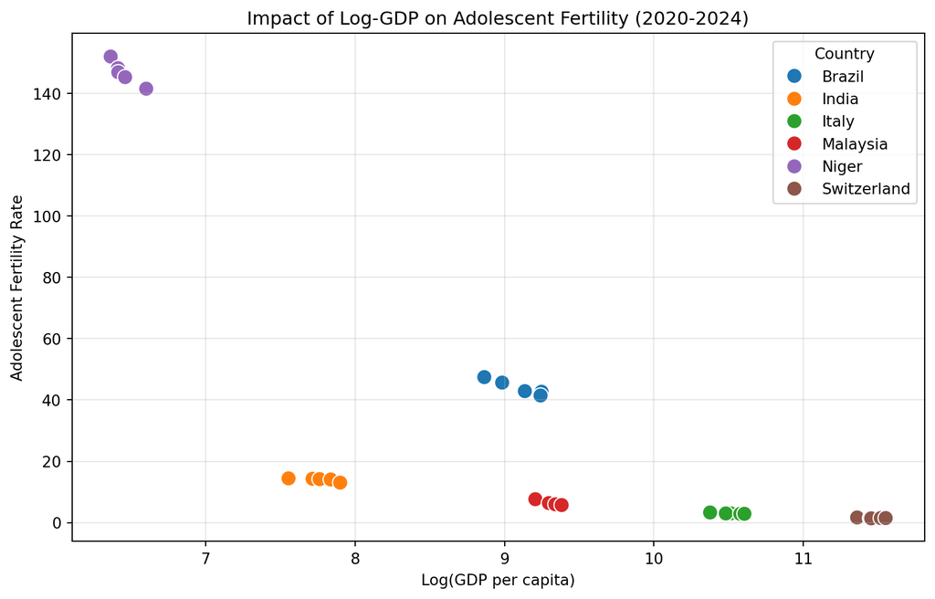

```python
import pandas as pd
import matplotlib.pyplot as plt
import seaborn as sns
import numpy as np


# Section: Log-Scale GDP Plot
plt.figure(figsize=(10, 6))
# Apply log transform to GDP for visual clarity
sns.scatterplot(data=df, x=np.log(df['gdp']), y='fertility', hue='Country', s=100)
plt.title('Impact of Log-GDP on Adolescent Fertility (2020-2024)')
plt.xlabel('Log(GDP per capita)')
plt.ylabel('Adolescent Fertility Rate')
plt.grid(True, alpha=0.3)
plt.show()
```

## Appendix 4

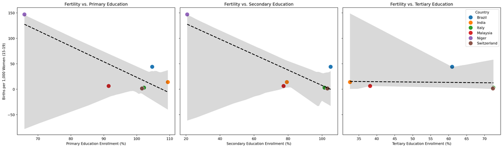

```python
import matplotlib.pyplot as plt
import seaborn as sns

df_1 = pd.read_csv('/Users/sissili/Desktop/QTM350/QTM_350_Final_Project/QTM350_Final_Project_Data/cleaned_final_project_data.csv')

# Set up a 3-panel figure to compare impact across tiers
fig, axes = plt.subplots(1, 3, figsize=(20, 6), sharey=True)

# List of education variables to plot
edu_vars = ['primary_edu', 'secondary_edu', 'tertiary_edu']
titles = ['Primary Education', 'Secondary Education', 'Tertiary Education']

for i, var in enumerate(edu_vars):
    # Plot on the specific subplot axis
    sns.scatterplot(
        data=df_1,
        x=var,
        y='fertility',
        hue='Country',
        s=150,
        ax=axes[i],
        legend=(i == 2) # Place legend only on the far right plot for clarity
    )

    # Add a global regression line to show the overall trend
    sns.regplot(
        data=df_1,
        x=var,
        y='fertility',
        scatter=False,
        color='black',
        line_kws={'linestyle':'--'},
        ax=axes[i]
    )

    axes[i].set_title(f'Fertility vs. {titles[i]}')
    axes[i].set_xlabel(f'{titles[i]} Enrollment (%)')

    # Only label the y-axis on the first plot to avoid clutter
    if i == 0:
        axes[i].set_ylabel('Births per 1,000 Women (15-19)')

plt.tight_layout()
plt.show()
```

## Reference

Abbasi, Muhammad Sajjad et al. 2024. “Association Between Education and Fertility: New Evidence from the Study in Pakistan.” *Children* 11 (10): 1234. https://doi.org/10.3390/children11101234.

Snopkowski, Kristin, Heidi Colleran, and Mary C Towner. 2016. “How Does Education Influence Fertility? Examining the Mediating Pathways in Ethiopia.” *Social Science & Medicine* 159: 27–36. https://doi.org/10.1016/j.socscimed.2016.04.037.

Viner, Russell M et al. 2017. “The Health Benefits of Secondary Education in Adolescents and Young Adults: An International Analysis in 186 Low-, Middle- and High-Income Countries from 1990 to 2013.” *The Lancet* 389 (10082): 149–59. https://doi.org/10.1016/S0140-6736(16)31321-4.